# Week 4 Lab

BU Bioinformatics

2024-09-28

# Lab 4 : Introduction to Making Your Own Reports

This week you’ll start making your own reports. Create your own knitted RMarkdown file and label the problems and solutions appropriately. There are two problems in this lab which are labeled “Part 1” and “Part 2”, as well as an extra credit section.

## Part 1 : RNA-Seq

Use the data provided to create the graphs and tables desired in 1.1-1.4. 1.3 and 1.4 also include some short answer questions.

### 1.0 : Loading and Exploring the Data

```r
## Importing libraries here
library(first_library_here)
library(second_library_here)
library(and_so_on)

## Data Loading for RNA-Seq
counts <- function_to_read_the_tsv("norm_counts_matrix.tsv")
results <- function_to_read_the_csv("rnaseq_results.csv")
```

### 1.1 : Visualize Up-Regulated and Down-Regulated Genes

Use the results of the differential expression analysis to create a volcano plot with the log2FoldChange on the x-axis and a scaled padj value on the y-axis. Color the points by significance. To read more about the volcano plot and differential expression, [consult section 9.7.9 in your textbook](https://bu-bioinfo.github.io/r-for-biological-sciences/biology-bioinformatics.html#differential-expression-rnaseq) (Volcano plot is at the end of 9.7.9.1)

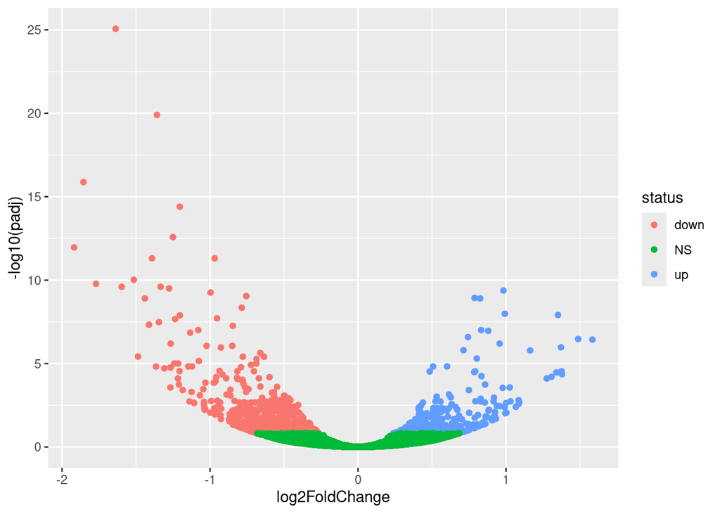

### 1.2 : Identify the Up- and Down-Regulated Genes

Create two tables from the differential expression results - one that contains only the up-regulated genes and a second one that contains only the down-regulated genes. The examples below use a different function than the ones you have learned in class, so do not worry if your output has different functionality.

|  | id | version | baseMean | log2FoldChange | lcfSE | stat | pvalue | padj | status |
| --- | --- | --- | --- | --- | --- | --- | --- | --- | --- |
| 1 | ENSMUSG00000017639 | 13 | 579.605269243739 | -1.63803611206866 | 0.144125118145433 | -11.3653756759857 | 6.219630952406359e-30 | 8.55696826432067e-26 | down |
| 2 | ENSMUSG00000022912 | 8 | 3961.51365853514 | -1.35855999704317 | 0.133086805362963 | -10.2080742966068 | 1.82449818715485e-24 | 1.25507230294382e-20 | down |
| 3 | ENSMUSG00000055027 | 17 | 328.996291325539 | -1.85500170908918 | 0.201127806811726 | -9.22299973581291 | 2.88902537242051e-20 | 1.32490703579205e-16 | down |
| 4 | ENSMUSG00000075254 | 11 | 10693.7650028687 | -1.20420627087964 | 0.136554593005692 | -8.81849701554482 | 1.16006296719578e-18 | 3.99003657566987e-15 | down |
| 5 | ENSMUSG00000032946 | 16 | 439.631111121773 | -1.25064439615276 | 0.15050048837544 | -8.30990257674708 | 9.57806756131434e-17 | 2.63550107017125e-13 | down |
| 6 | ENSMUSG00000027875 | 12 | 2073.77255952475 | -1.9182063311749 | 0.236296561358851 | -8.11779198200783 | 4.74741603359729e-16 | 1.08858249650386e-12 | down |
| 7 | ENSMUSG00000026043 | 18 | 43664.5922106748 | -1.39221638240669 | 0.176225900369285 | -7.90018027707204 | 2.78500330049236e-15 | 4.92236768778463e-12 | down |
| 8 | ENSMUSG00000025780 | 7 | 59338.4994052333 | -0.968839629945898 | 0.12268810327629 | -7.89676915751239 | 2.86225770477373e-15 | 4.92236768778463e-12 | down |
| 9 | ENSMUSG00000022037 | 14 | 4745.87538626048 | -1.5151714690953 | 0.201909834465538 | -7.50419846118945 | 6.18056065830622e-14 | 9.448017059664119e-11 | down |
| 10 | ENSMUSG00000104802 | 1 | 299.378487839086 | -1.77090877692082 | 0.238755295992171 | -7.41725443015466 | 1.19573110278714e-13 | 1.64508685121455e-10 | down |

[output cut: 326 more lines]

|  | id | version | baseMean | log2FoldChange | lcfSE | stat | pvalue | padj | status |
| --- | --- | --- | --- | --- | --- | --- | --- | --- | --- |
| 1 | ENSMUSG00000030751 | 18 | 18552.6057117361 | 0.98261549770117 | 0.135584134160673 | 7.2472749395348 | 4.25240219357087e-13 | 4.17889638422486e-10 | up |
| 2 | ENSMUSG00000031903 | 6 | 11463.175009199 | 0.787607602473003 | 0.111254171113345 | 7.07935347134617 | 1.44828543687873e-12 | 1.17208888473986e-09 | up |
| 3 | ENSMUSG00000050708 | 16 | 48530.7785366953 | 0.825195110038358 | 0.116954191688791 | 7.05571213928065 | 1.71718985201774e-12 | 1.25157384966232e-09 | up |
| 4 | ENSMUSG00000048758 | 13 | 946.243447896308 | 0.992001329769946 | 0.147177535257625 | 6.74016811080245 | 1.58203479427916e-11 | 1.03645879522346e-08 | up |
| 5 | ENSMUSG00000049422 | 6 | 2544.58844218653 | 1.35107376363881 | 0.201357984835605 | 6.70980971895338 | 1.94878367348848e-11 | 1.21869844453884e-08 | up |
| 6 | ENSMUSG00000018796 | 13 | 161524.645632683 | 0.832024088491606 | 0.130939457321863 | 6.35426559349794 | 2.09424726780821e-10 | 9.80935835916573e-08 | up |
| 7 | ENSMUSG00000062382 | 7 | 1208.27780266025 | 0.879793137242223 | 0.13901794139208 | 6.32863016408 | 2.4734715623583e-10 | 1.09774263725566e-07 | up |
| 8 | ENSMUSG00000016319 | 3 | 27125.3689290266 | 0.742898128282191 | 0.120108185581891 | 6.18524145280403 | 6.20074862888181e-10 | 2.58514847382291e-07 | up |
| 9 | ENSMUSG00000034780 | 6 | 221.126397990256 | 1.48769018382699 | 0.242378155698324 | 6.1378888684946 | 8.36253273309802e-10 | 3.38387427476361e-07 | up |
| 10 | ENSMUSG00000026452 | 15 | 238.671639683304 | 1.58387818516534 | 0.258804865540159 | 6.11997066538756 | 9.3592585678654e-10 | 3.67899083933406e-07 | up |

[output cut: 142 more lines]

### 1.3 : Visualize Some Significant Genes

Using the volcano plot you made in 1.1 and the tables you made in 1.2, pick 3 genes that were found to be significant (padj< 0.05) in the differential expression and visualize them. Pick a method of displaying these genes that makes the most sense to you. Three examples are included below, but they may not be the one that will work best for you.

In your report, write a couple of sentences with your graph(s) explaining: - Why did you choose these genes to plot? - What do you notice about the data?

[figure not shown]

```
## # A tibble: 8 × 3
##   GeneID               sample           normCounts
##   <chr>                <chr>                 <dbl>
## 1 ENSMUSG00000034780.6 EPI_ADIPO_KO_840      168.
## 2 ENSMUSG00000034780.6 EPI_ADIPO_KO_843      179.
## 3 ENSMUSG00000034780.6 EPI_ADIPO_KO_857      399.
## 4 ENSMUSG00000034780.6 EPI_ADIPO_KO_891      186.
## 5 ENSMUSG00000034780.6 EPI_ADIPO_WT_841       32.6
## 6 ENSMUSG00000034780.6 EPI_ADIPO_WT_842       33.7
## 7 ENSMUSG00000034780.6 EPI_ADIPO_WT_858       70.8
## 8 ENSMUSG00000034780.6 EPI_ADIPO_WT_892       79.1
```

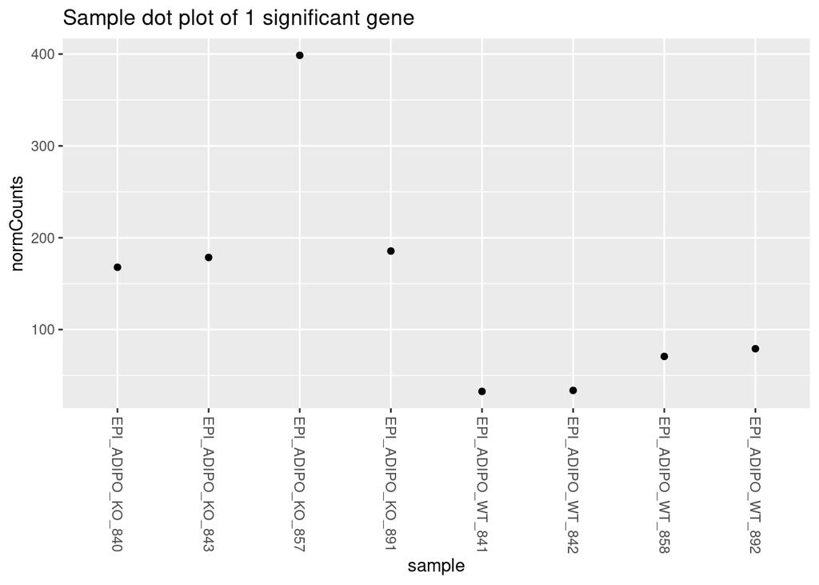

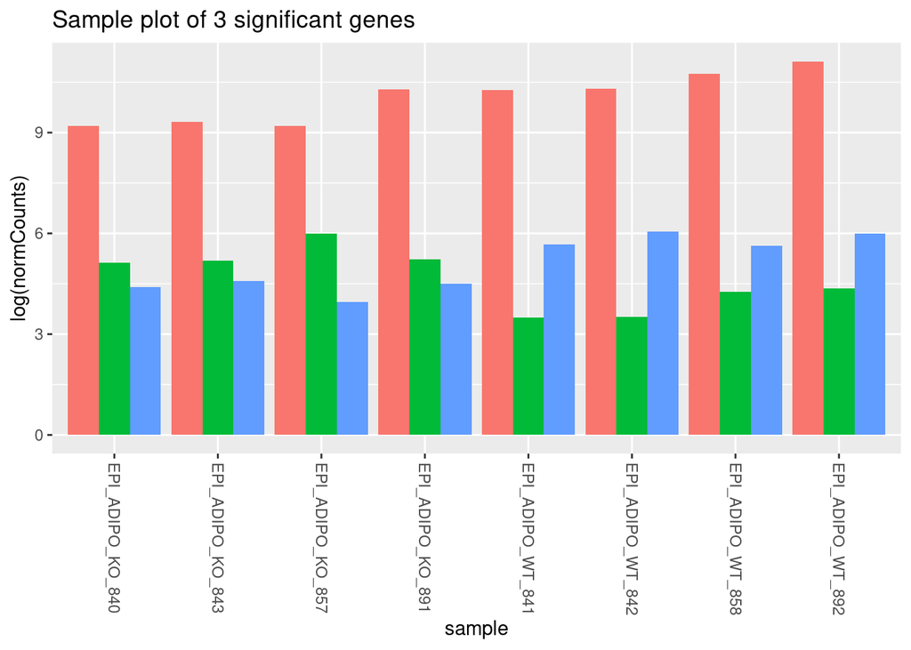

### 1.4 : Visualize Some Insiginificant Genes

Pick 3 genes that were NOT significant (padj > 0.05) and visualize them like you did in 1.3. See above for examples. For this one, write a short sentence or two about your observations in plotting these insignificant genes vs the significant ones you plotted in 1.3.

## Part 2 : Single Cell

Use the data from `single_cell_data.csv` to create the graphs desired in 2.1 and 2.2. The data provided to you is a table that shows the number cells per category that were identified in each sample.

### 2.0 : Loading the Data

Just like the RNA-Seq problem, you will need to load in the data and take a look at it. You do not need to display the unprocessed data in your report.

```r
## Importing any extra libraries here
library(extra_library_here)

## Data Loading for RNA-Seq
sc <- function_to_read_the_csv("single_cell_data.csv")
```

### 2.1 : Chart Relative Cell Types - By Quantity

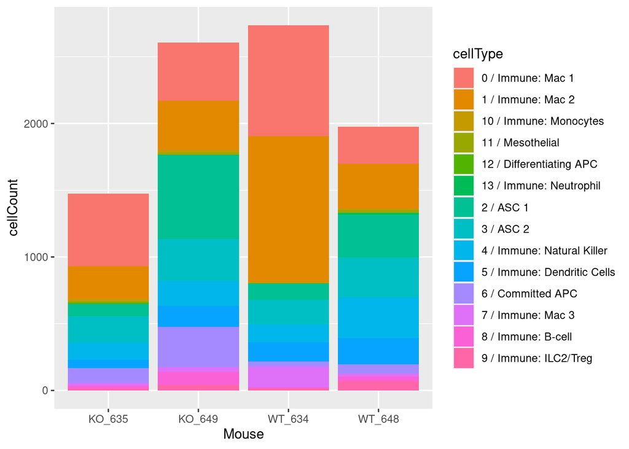

### 2.2 : Chart Relative Cell Types - By Proportion

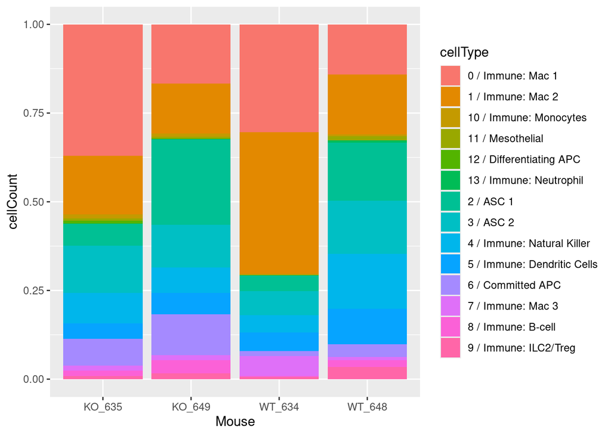

## Extra Credit : Improve Visuals

Now that you have made the base graphs, “pretty” them up in so that they look nicer and are easier to read. If you decide to do the extra credit, please include a brief write-up (1 sentence to 1 small paragraph) in your report detailing what you did to improve the graph.

Ways you can improve your graphs include: their colors so it is easier to distinguish sets apart, varying the shape of your points, sizing your graphs to fit the knitted document, adjusting parameters to make things easier to read, adjusting labels… whatever you can do to make your presentation easier to read.

In some cases, you may want to fundamentally change the graph by removing unnecessary categories, combining categories, subdividing the graph, changing the type of graph it is, or anything else that makes sense. If you do this, please create a second set of graphs - the original and the extra credit version below it in the same section. Include your brief description of your improvements with the extra credit graph.

A Note on Color Selection : Please be aware of that not everyone can see colors the same way you do when you are selecting colors for your graph, if you choose to select colors. Two colors may be aesthetically pleasing to one person, and virtually identical to another. If you are interested here’s some [tips for colorblind-safe graphs](https://blogs.sas.com/content/iml/2023/01/30/tips-colorblind-safe-graphs.html)